# Introduction

This data set contains information about 10,000 movies collected from The Movie Database (TMDb), including user ratings and revenue.

The final two columns ending with “_adj” show the budget and revenue of the associated movie in terms of 2010 dollars, accounting for inflation over time.

Importing libraries to query data and visual display

```python
import pandas as pd
import numpy as np
import matplotlib.pyplot as plt
import seaborn as sns
% matplotlib inline
```

# Data Wrangling

## General Properties

- Loading dataset 'tmdb-movies.csv'

```python
df = pd.read_csv('tmdb-movies.csv')
df.head()
```

|  | id | imdb_id | popularity | budget | revenue | original_title | cast | homepage | director | tagline | ... | overview | runtime | genres | production_companies | release_date | vote_count | vote_average | release_year | budget_adj | revenue_adj |
| --- | --- | --- | --- | --- | --- | --- | --- | --- | --- | --- | --- | --- | --- | --- | --- | --- | --- | --- | --- | --- | --- |
| 0 | 135397 | tt0369610 | 32.985763 | 150000000 | 1513528810 | Jurassic World | Chris Pratt\|Bryce Dallas Howard\|Irrfan Khan\|Vi... | http://www.jurassicworld.com/ | Colin Trevorrow | The park is open. | ... | Twenty-two years after the events of Jurassic ... | 124 | Action\|Adventure\|Science Fiction\|Thriller | Universal Studios\|Amblin Entertainment\|Legenda... | 6/9/15 | 5562 | 6.5 | 2015 | 1.379999e+08 | 1.392446e+09 |
| 1 | 76341 | tt1392190 | 28.419936 | 150000000 | 378436354 | Mad Max: Fury Road | Tom Hardy\|Charlize Theron\|Hugh Keays-Byrne\|Nic... | http://www.madmaxmovie.com/ | George Miller | What a Lovely Day. | ... | An apocalyptic story set in the furthest reach... | 120 | Action\|Adventure\|Science Fiction\|Thriller | Village Roadshow Pictures\|Kennedy Miller Produ... | 5/13/15 | 6185 | 7.1 | 2015 | 1.379999e+08 | 3.481613e+08 |
| 2 | 262500 | tt2908446 | 13.112507 | 110000000 | 295238201 | Insurgent | Shailene Woodley\|Theo James\|Kate Winslet\|Ansel... | http://www.thedivergentseries.movie/#insurgent | Robert Schwentke | One Choice Can Destroy You | ... | Beatrice Prior must confront her inner demons ... | 119 | Adventure\|Science Fiction\|Thriller | Summit Entertainment\|Mandeville Films\|Red Wago... | 3/18/15 | 2480 | 6.3 | 2015 | 1.012000e+08 | 2.716190e+08 |
| 3 | 140607 | tt2488496 | 11.173104 | 200000000 | 2068178225 | Star Wars: The Force Awakens | Harrison Ford\|Mark Hamill\|Carrie Fisher\|Adam D... | http://www.starwars.com/films/star-wars-episod... | J.J. Abrams | Every generation has a story. | ... | Thirty years after defeating the Galactic Empi... | 136 | Action\|Adventure\|Science Fiction\|Fantasy | Lucasfilm\|Truenorth Productions\|Bad Robot | 12/15/15 | 5292 | 7.5 | 2015 | 1.839999e+08 | 1.902723e+09 |
| 4 | 168259 | tt2820852 | 9.335014 | 190000000 | 1506249360 | Furious 7 | Vin Diesel\|Paul Walker\|Jason Statham\|Michelle ... | http://www.furious7.com/ | James Wan | Vengeance Hits Home | ... | Deckard Shaw seeks revenge against Dominic Tor... | 137 | Action\|Crime\|Thriller | Universal Pictures\|Original Film\|Media Rights ... | 4/1/15 | 2947 | 7.3 | 2015 | 1.747999e+08 | 1.385749e+09 |

5 rows × 21 columns

# Data Cleaning

- Using info() we can check for non null values in each column , number of rows/columns and data types for each column

```python
df.info()
```

```
<class 'pandas.core.frame.DataFrame'>
RangeIndex: 10866 entries, 0 to 10865
Data columns (total 21 columns):
id                      10866 non-null int64
imdb_id                 10856 non-null object
popularity              10866 non-null float64
budget                  10866 non-null int64
revenue                 10866 non-null int64
original_title          10866 non-null object
cast                    10790 non-null object
homepage                2936 non-null object
director                10822 non-null object
tagline                 8042 non-null object
keywords                9373 non-null object
overview                10862 non-null object
runtime                 10866 non-null int64
genres                  10843 non-null object
production_companies    9836 non-null object
release_date            10866 non-null object
vote_count              10866 non-null int64
vote_average            10866 non-null float64
release_year            10866 non-null int64
budget_adj              10866 non-null float64
revenue_adj             10866 non-null float64
dtypes: float64(4), int64(6), object(11)
memory usage: 1.7+ MB
```

```python
df.shape
```

```
(10866, 21)
```

```python
df.dtypes
```

```
id                        int64
imdb_id                  object
popularity              float64
budget                    int64
revenue                   int64
original_title           object
cast                     object
homepage                 object
director                 object
tagline                  object
keywords                 object
overview                 object
runtime                   int64
genres                   object
production_companies     object
release_date             object
vote_count                int64
vote_average            float64
release_year              int64
budget_adj              float64
revenue_adj             float64
dtype: object
```

```python
df.nunique()
```

```
id                      10865
imdb_id                 10855
popularity              10814
budget                    557
revenue                  4702
original_title          10571
cast                    10719
homepage                 2896
director                 5067
tagline                  7997
keywords                 8804
overview                10847
runtime                   247
genres                   2039
production_companies     7445
release_date             5909
vote_count               1289
vote_average               72
release_year               56
budget_adj               2614
revenue_adj              4840
dtype: int64
```

```python
df.describe()
```

|  | id | popularity | budget | revenue | runtime | vote_count | vote_average | release_year | budget_adj | revenue_adj |
| --- | --- | --- | --- | --- | --- | --- | --- | --- | --- | --- |
| count | 10866.000000 | 10866.000000 | 1.086600e+04 | 1.086600e+04 | 10866.000000 | 10866.000000 | 10866.000000 | 10866.000000 | 1.086600e+04 | 1.086600e+04 |
| mean | 66064.177434 | 0.646441 | 1.462570e+07 | 3.982332e+07 | 102.070863 | 217.389748 | 5.974922 | 2001.322658 | 1.755104e+07 | 5.136436e+07 |
| std | 92130.136561 | 1.000185 | 3.091321e+07 | 1.170035e+08 | 31.381405 | 575.619058 | 0.935142 | 12.812941 | 3.430616e+07 | 1.446325e+08 |
| min | 5.000000 | 0.000065 | 0.000000e+00 | 0.000000e+00 | 0.000000 | 10.000000 | 1.500000 | 1960.000000 | 0.000000e+00 | 0.000000e+00 |
| 25% | 10596.250000 | 0.207583 | 0.000000e+00 | 0.000000e+00 | 90.000000 | 17.000000 | 5.400000 | 1995.000000 | 0.000000e+00 | 0.000000e+00 |
| 50% | 20669.000000 | 0.383856 | 0.000000e+00 | 0.000000e+00 | 99.000000 | 38.000000 | 6.000000 | 2006.000000 | 0.000000e+00 | 0.000000e+00 |
| 75% | 75610.000000 | 0.713817 | 1.500000e+07 | 2.400000e+07 | 111.000000 | 145.750000 | 6.600000 | 2011.000000 | 2.085325e+07 | 3.369710e+07 |
| max | 417859.000000 | 32.985763 | 4.250000e+08 | 2.781506e+09 | 900.000000 | 9767.000000 | 9.200000 | 2015.000000 | 4.250000e+08 | 2.827124e+09 |

# Histogram on df shows visually how over all data frame look like.

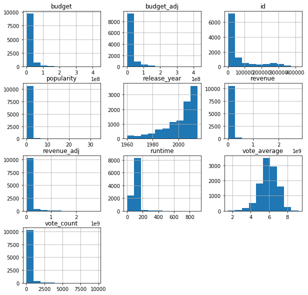

```python
df.hist(figsize=(10,10));
```

```python
# Checking for duplicated values and then dropping duplicates.
df.duplicated().sum()
```

```
1
```

```python
df.drop_duplicates(inplace=True)
```

```python
# Checking for null values now and then dropping them.
df.isnull().sum()
```

```
id                         0
imdb_id                   10
popularity                 0
budget                     0
revenue                    0
original_title             0
cast                      76
homepage                7929
director                  44
tagline                 2824
keywords                1493
overview                   4
runtime                    0
genres                    23
production_companies    1030
release_date               0
vote_count                 0
vote_average               0
release_year               0
budget_adj                 0
revenue_adj                0
dtype: int64
```

We can also fill with mean value if null values mostly from numerical (integer or float) but as we got homepage, tagline, keywords and production companies which are all non-numerical (object or string) so can't refill it with means so droping them instead.

```python
df.dropna(inplace=True)
df.isnull().sum()
```

```
id                      0
imdb_id                 0
popularity              0
budget                  0
revenue                 0
original_title          0
cast                    0
homepage                0
director                0
tagline                 0
keywords                0
overview                0
runtime                 0
genres                  0
production_companies    0
release_date            0
vote_count              0
vote_average            0
release_year            0
budget_adj              0
revenue_adj             0
dtype: int64
```

# Exploratory Data Analysis

## Which genres are most popular from year to year?

Checking with scatter matrix if it point out to anything obvious.

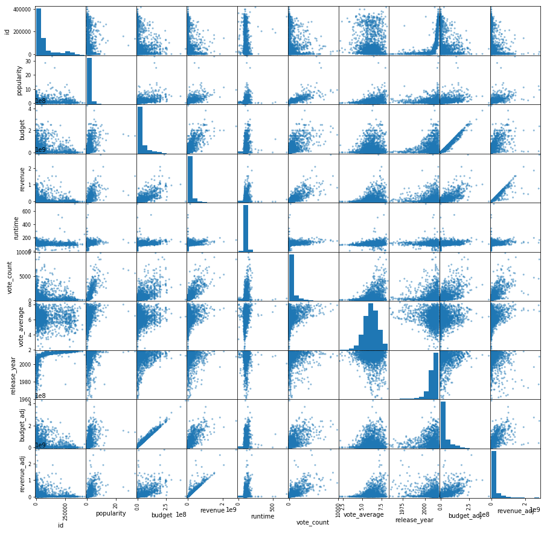

```python
pd.plotting.scatter_matrix(df,figsize=(15,15));
```

```python
grouped_df = df[['release_year', 'genres','popularity']].groupby(['release_year','genres']).sum()
grouped_df = grouped_df.loc[grouped_df.groupby(level='release_year')['popularity'].idxmax()]
grouped_df = grouped_df.reset_index(level=['release_year', 'genres'])
grouped_df
```

|  | release_year | genres | popularity |
| --- | --- | --- | --- |
| 0 | 1961 | Comedy\|Family | 0.303783 |
| 1 | 1962 | Adventure\|Action\|Thriller | 3.170651 |
| 2 | 1963 | Action\|Thriller\|Adventure | 2.508235 |
| 3 | 1964 | Adventure\|Action\|Thriller | 3.153791 |
| 4 | 1965 | Adventure\|Action\|Thriller | 1.910465 |
| 5 | 1967 | Action\|Thriller\|Adventure | 1.554808 |
| 6 | 1969 | Adventure\|Action\|Thriller | 1.778746 |
| 7 | 1970 | Comedy\|Drama\|Thriller | 0.374514 |
| 8 | 1971 | Adventure\|Action\|Thriller\|Science Fiction | 1.755117 |
| 9 | 1972 | Drama\|Crime | 5.738034 |
| 10 | 1973 | Drama\|Horror\|Thriller | 2.010733 |
| 11 | 1974 | Adventure\|Action\|Thriller | 1.619555 |
| 12 | 1975 | Horror\|Thriller\|Adventure | 2.563191 |
| 13 | 1976 | Action\|Crime | 0.374631 |
| 14 | 1977 | Adventure\|Action\|Science Fiction | 12.037933 |
| 15 | 1978 | Horror\|Thriller | 1.198849 |
| 16 | 1979 | Horror\|Action\|Thriller\|Science Fiction | 4.935897 |
| 17 | 1980 | Adventure\|Action\|Science Fiction | 5.488441 |
| 18 | 1981 | Adventure\|Action | 4.578300 |
| 19 | 1982 | Science Fiction\|Drama\|Thriller | 4.215642 |
| 20 | 1983 | Adventure\|Action\|Science Fiction | 4.828854 |
| 21 | 1984 | Action\|Thriller\|Science Fiction | 4.831966 |
| 22 | 1985 | Adventure\|Comedy\|Science Fiction\|Family | 6.095293 |
| 23 | 1986 | Adventure\|Fantasy\|Action\|Comedy | 0.960984 |
| 24 | 1987 | Drama\|Music\|Romance | 1.945847 |
| 25 | 1988 | Action\|Horror\|Science Fiction\|Thriller | 1.078884 |
| 26 | 1989 | Adventure\|Action | 3.536655 |
| 27 | 1990 | Adventure\|Action\|Comedy\|Science Fiction\|Family | 2.441201 |
| 28 | 1991 | Romance\|Family\|Animation\|Fantasy\|Music | 3.852269 |
| 29 | 1992 | Animation\|Family\|Comedy\|Adventure\|Fantasy | 3.966538 |
| 30 | 1993 | Drama\|History\|War | 2.377288 |
| 31 | 1994 | Family\|Animation\|Drama | 4.782688 |
| 32 | 1995 | Crime\|Mystery\|Thriller | 4.765359 |
| 33 | 1996 | Adventure\|Action\|Thriller | 3.293387 |
| 34 | 1997 | Drama\|Romance\|Thriller | 4.355219 |
| 35 | 1998 | Comedy\|Crime | 3.255089 |
| 36 | 1999 | Drama | 15.668337 |
| 37 | 2000 | Mystery\|Thriller | 3.095625 |
| 38 | 2001 | Adventure\|Fantasy\|Action | 8.575419 |
| 39 | 2002 | Adventure\|Fantasy\|Action | 8.095275 |
| 40 | 2003 | Adventure\|Fantasy\|Action | 13.986522 |
| 41 | 2004 | Drama | 5.131322 |
| 42 | 2005 | Adventure\|Fantasy\|Family | 5.939927 |
| 43 | 2006 | Adventure\|Action\|Thriller | 6.887631 |
| 44 | 2007 | Comedy | 5.780700 |
| 45 | 2008 | Animation\|Family | 10.041709 |
| 46 | 2009 | Comedy | 11.175404 |
| 47 | 2010 | Drama | 11.344642 |
| 48 | 2011 | Comedy | 18.293226 |
| 49 | 2012 | Comedy | 9.785633 |
| 50 | 2013 | Horror\|Thriller | 7.063328 |
| 51 | 2014 | Adventure\|Drama\|Science Fiction | 24.949134 |
| 52 | 2015 | Action\|Adventure\|Science Fiction\|Thriller | 61.405699 |

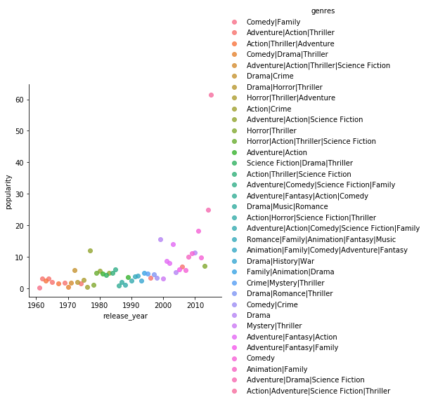

```python
sns.lmplot('release_year', 'popularity', data=grouped_df, hue='genres', fit_reg=False)
plt.show()
```

# Question 2: Which most common Genre movie earn most?

Firstly we try to find out Genres top most category and then we will narrow it down to which movie which had earned most.

```python
df['genres'].describe()
df_drama= df[df['genres']== 'Drama']
df_drama.head(1)
```

|  | id | imdb_id | popularity | budget | revenue | original_title | cast | homepage | director | tagline | ... | overview | runtime | genres | production_companies | release_date | vote_count | vote_average | release_year | budget_adj | revenue_adj |
| --- | --- | --- | --- | --- | --- | --- | --- | --- | --- | --- | --- | --- | --- | --- | --- | --- | --- | --- | --- | --- | --- |
| 55 | 295964 | tt2503944 | 2.584264 | 20000000 | 36606743 | Burnt | Bradley Cooper\|Sienna Miller\|Lily James\|Alicia... | http://burntmovie.com/ | John Wells | Never underestimate a man with everything to l... | ... | Adam Jones is a Chef who destroyed his career ... | 100 | Drama | Double Feature Films\|PeaPie Films\|3 Arts Enter... | 10/2/15 | 631 | 6.3 | 2015 | 1.839999e+07 | 3.367819e+07 |

1 rows × 21 columns

```python
df_drama.groupby('revenue').max()
```

| revenue | id | imdb_id | popularity | budget | original_title | cast | homepage | director | tagline | keywords | overview | runtime | genres | production_companies | release_date | vote_count | vote_average | release_year | budget_adj | revenue_adj |
| --- | --- | --- | --- | --- | --- | --- | --- | --- | --- | --- | --- | --- | --- | --- | --- | --- | --- | --- | --- | --- |
| 0 | 339145 | tt3720788 | 1.191423 | 21000000 | You Don't Know Jack | Werner Schünemann\|Renato Prieto\|Fernando Alve... | https://www.facebook.com/WildBillFilm | Wagner de Assis | When We Are Pushed To The Edge We Discover The... | wrestling\|sport\|independent film\|family relati... | When a high school football star is suddenly s... | 336 | Drama | Zentropa Entertainments | 9/9/10 | 232 | 7.1 | 2015 | 2.134441e+07 | 0.000000e+00 |
| 6420 | 174341 | tt2231138 | 0.466719 | 0 | Some Velvet Morning | Stanley Tucci\|Alice Eve | http://tribecafilm.com/tribecafilm/filmguide/s... | Neil LaBute | Unsettling and unforgettable | prostitute\|infidelity | Fred (Stanley Tucci) arrives at the doorstep o... | 82 | Drama | Untouchable Films\|Velvet Morning | 12/10/13 | 17 | 5.6 | 2013 | 0.000000e+00 | 6.009334e+03 |
| 32251 | 244783 | tt2182972 | 0.407983 | 6000000 | Song One | Anne Hathaway\|Johnny Flynn\|Mary Steenburgen\|Be... | http://songonemovie.tumblr.com/ | Kate Barker-Froyland | A moment can change everything. | woman director | Estranged from her family, Franny returns home... | 86 | Drama | Worldview Entertainment | 1/20/14 | 58 | 5.7 | 2014 | 5.526546e+06 | 2.970611e+04 |
| 35022 | 154282 | tt2364949 | 0.216200 | 0 | Touchy Feely | Ellen Page\|Rosemarie DeWitt\|Scoot McNairy\|Alli... | http://www.magpictures.com/touchyfeely/ | Lynn Shelton | A self-improved comedy | therapist\|massage\|contact\|masseuse\|kiss | Abby is a sought after massage therapist and a... | 89 | Drama | Lynn Shelton | 1/19/13 | 22 | 5.4 | 2013 | 0.000000e+00 | 3.278176e+04 |
| 44348 | 33997 | tt1054580 | 0.370172 | 0 | Desert Flower | Liya Kebede\|Sally Hawkins\|Craig Parkinson\|Meer... | http://www.desertflower-movie.com/ | Sherry Hormann | The extraordinary true story of the woman who ... | female nudity\|africa\|rape\|based on novel\|vagabund | The autobiography of a Somalian nomad circumci... | 120 | Drama | Desert Flower Filmproductions\|Desert Flower\|Ba... | 9/24/09 | 42 | 7.3 | 2009 | 0.000000e+00 | 4.507533e+04 |
| 48390 | 177047 | tt1464191 | 0.688179 | 2000000 | Decoding Annie Parker | Samantha Morton\|Helen Hunt\|Aaron Paul\|Alice Ev... | http://www.decodingannieparkerfilm.com/ | Steven Bernstein | Everyone thought they were crazy, until they p... | infidelity\|genetics\|black comedy\|cancer\|dna te... | The lives of a breast-cancer patient and a res... | 91 | Drama | Media House Capital\|Unified Pictures\|Decoding ... | 5/2/14 | 23 | 5.2 | 2014 | 1.842182e+06 | 4.457160e+04 |
| 63931 | 59437 | tt1533013 | 0.245438 | 0 | Beautiful Boy | Michael Sheen\|Maria Bello\|Alan Tudyk\|Moon Bloo... | http://www.beautifulboythemovie.com/ | Shawn Ku | To confront the truth, first they had to face ... | forgiveness\|victim\|collage\|grief\|independent film | A married couple on the verge of separation ar... | 100 | Drama | First Point Entertainment\|Braeburn Entertainment | 9/12/10 | 13 | 5.9 | 2010 | 0.000000e+00 | 6.393100e+04 |
| 165000 | 13185 | tt0435680 | 0.461865 | 994000 | Kidulthood | Aml Ameen\|Red Madrell\|Noel Clarke\|Adam Deacon\|... | http://www.kidulthood.co.uk/ | Menhaj Huda | Before adulthood comes... | independent film | A day in the life of a group of troubled 15-ye... | 89 | Drama | Cipher Films\|Stealth Films Limited\|TMC Films | 3/3/06 | 25 | 6.5 | 2006 | 1.075179e+06 | 1.784754e+05 |
| 187674 | 273899 | tt3018070 | 0.076109 | 13500000 | Stonewall | Jeremy Irvine\|Jonny Beauchamp\|Jonathan Rhys Me... | https://twitter.com/Stonewall_Movie | Roland Emmerich | Where Pride Began | stonewall riot | "Stonewall" is a drama about a young man in Ne... | 129 | Drama | Centropolis Entertainment\|Mel's Cite du Cinema | 9/18/15 | 14 | 5.6 | 2015 | 1.241999e+07 | 1.726600e+05 |
| 253899 | 56401 | tt1613062 | 0.352084 | 4000000 | The Music Never Stopped | J.K. Simmons\|Lou Taylor Pucci\|Julia Ormond\|Car... | http://themusicneverstopped-movie.com/ | Jim Kohlberg | No matter how lost you are, music can bring yo... | independent film | Tale of a father who struggles to bond with hi... | 105 | Drama | Mr. Tamborine Man\|Essential Pictures | 3/18/11 | 31 | 7.3 | 2011 | 3.877592e+06 | 2.461292e+05 |
| 382946 | 44835 | tt1403177 | 0.564203 | 7000000 | Hesher | Joseph Gordon-Levitt\|Natalie Portman\|Rainn Wil... | http://www.hesherthemovie.com/ | Spencer Susser | Sometimes life gives you the finger and someti... | loss of mother\|clerk\|grocery\|loss of relative\|... | A young boy has lost his mother and is losing ... | 106 | Drama | DRO Entertainment\|The Last Picture Company\|Cat... | 1/22/10 | 104 | 6.2 | 2010 | 7.000000e+06 | 3.829460e+05 |
| 430041 | 43920 | tt1422020 | 0.478118 | 0 | Dog Pound | Adam Butcher\|Shane Kippel\|Mateo Morales\|Taylor... | http://www.dogpound-lefilm.com/ | Kim Chapiron | Fighting Back Is The Only Way Out | juvenile prison\|sodomy\|incest overtones | Three juvenile delinquents arrive at a correct... | 91 | Drama | Angoa-Agicoa\|Téléfilm Canada\|Mars Films\|Part... | 4/24/10 | 53 | 7.7 | 2010 | 0.000000e+00 | 4.300410e+05 |
| 617000 | 38568 | tt1049402 | 0.275607 | 30000 | Howl | James Franco\|Jon Hamm\|Mary-Louise Parker\|Treat... | http://howlthemovie.com/ | Rob Epstein\|Jeffrey Friedman | The Obscenity Trial That Started a Revolution.... | poetry\|literature\|freedom\|homosexuality\|indepe... | It's San Francisco in 1957, and an American ma... | 84 | Drama | RabbitBandini Productions\|Werc Werk Works | 8/26/10 | 45 | 6.8 | 2010 | 3.000000e+04 | 6.170000e+05 |
| 634074 | 18484 | tt0413466 | 0.021261 | 0 | Wassup Rockers | Jonathan Velasquez\|Francisco Pedrasa\|Milton Ve... | http://www.wassuprockers.net/ | Larry Clark | From South Central to Beverly Hills | independent film | Instead of adhering to the norms of their Sout... | 111 | Drama | Glass Key\|Wildcard Productions | 9/12/05 | 12 | 5.9 | 2005 | 0.000000e+00 | 7.079838e+05 |
| 970816 | 50780 | tt1321860 | 0.903312 | 21000000 | The Beaver | Jodie Foster\|Mel Gibson\|Jennifer Lawrence\|Anto... | http://www.thebeaver-movie.com/ | Jodie Foster | He's here to save Walter's life. | puppet\|woman director | Suffering from a severe case of depression, to... | 91 | Drama | Summit Entertainment\|Participant Media\|Imagena... | 2/11/11 | 144 | 6.0 | 2011 | 2.035736e+07 | 9.411071e+05 |
| 985007 | 157829 | tt3729920 | 0.472242 | 0 | The Disappearance of Eleanor Rigby: Them | James McAvoy\|Jessica Chastain\|Ciarán Hinds\|Bi... | http://eleanorrigby-movie.com/ | Ned Benson | Two Films. One Love. | new york\|couple\|loss of a child | A New York couple's relationship is tested aft... | 119 | Drama | Myriad Pictures\|Unison Films\|Kim and Jim Produ... | 5/14/14 | 74 | 6.4 | 2014 | 0.000000e+00 | 9.072811e+05 |
| 1600000 | 169813 | tt2370248 | 1.333929 | 0 | Short Term 12 | Brie Larson\|John Gallagher Jr.\|Kaitlyn Dever\|R... | http://www.shortterm12.com/ | Destin Cretton | Support them. Take care of them. But don't bec... | child abuse\|suicide attempt\|social worker\|base... | Grace, a compassionate young supervisor at a f... | 96 | Drama | Traction Media\|Animal Kingdom | 8/23/13 | 301 | 7.8 | 2013 | 0.000000e+00 | 1.497653e+06 |
| 2360281 | 284276 | tt3442006 | 2.692691 | 7000000 | Cake | Jennifer Aniston\|Anna Kendrick\|William H. Macy... | http://cakemovie.net/ | Daniel Barnz | Forgiveness is a bitter pill to swallow. | suicide\|support group\|depression\|widower\|grieving | After having visions of a member of her suppor... | 102 | Drama | Echo Films\|We're Not Brothers Productions\|Cine... | 9/7/14 | 255 | 6.1 | 2014 | 6.447637e+06 | 2.174034e+06 |
| 2849142 | 3877 | tt0469623 | 0.408767 | 16000000 | Things We Lost in the Fire | Halle Berry\|Benicio del Toro\|David Duchovny\|Al... | http://www.thingswelostinthefiremovie.com/ | Susanne Bier | Hope comes with letting go. | sadness\|loss of father\|junkie\|luxury\|heroin | A recent widow invites her husband's troubled ... | 113 | Drama | DreamWorks SKG\|Neal Street Productions\|DreamWo... | 9/26/07 | 40 | 6.5 | 2007 | 1.682670e+07 | 2.996353e+06 |
| 4882577 | 44129 | tt1172991 | 0.892356 | 15000000 | The Company Men | Ben Affleck\|Tommy Lee Jones\|Chris Cooper\|Kevin... | http://www.companymenmovie.com/ | John Wells | In America, we give our lives to our jobs. It'... | stock price\|corporate\|carpenter\|job hunting | Bobby Walker is living the proverbial American... | 104 | Drama | Spring Creek Productions\|Battle Mountain Films | 10/21/10 | 133 | 6.4 | 2010 | 1.500000e+07 | 4.882577e+06 |
| 5634828 | 73873 | tt1602098 | 0.283696 | 8000000 | Albert Nobbs | Glenn Close\|Mia Wasikowska\|Aaron Taylor-Johnso... | http://albertnobbs-themovie.com | Rodrigo García | A man with a secret. A woman with a dream. | butler\|dublin\|maid | Albert Nobbs struggles to survive in late 19th... | 113 | Drama | Chrysalis Films | 12/21/11 | 68 | 6.1 | 2011 | 7.755184e+06 | 5.462391e+06 |
| 6063556 | 49014 | tt1480656 | 0.359578 | 20500000 | Cosmopolis | Robert Pattinson\|Sarah Gadon\|Juliette Binoche\|... | http://cosmopolisthefilm.com | David Cronenberg | How far can he go before he goes too far? | taxi\|sex\|bookshop\|taxi driver\|nudity | Riding across Manhattan in a stretch limo in o... | 109 | Drama | France 2 Cinéma\|Téléfilm Canada\|Rai Cinema\|... | 5/25/12 | 191 | 4.8 | 2012 | 1.946976e+07 | 5.758828e+06 |
| 6732980 | 45094 | tt1244754 | 0.773316 | 12500000 | Conviction | Hilary Swank\|Minnie Driver\|Bailee Madison\|Lore... | http://www.foxsearchlight.com/conviction/ | Tony Goldwyn | An extraordinary journey of how far we go to f... | prison\|brother sister relationship\|law school | When Betty Anne Waters' older brother Kenny is... | 107 | Drama | Oceana Media Finance\|Pantheon Entertainment Co... | 9/11/10 | 87 | 7.0 | 2010 | 1.250000e+07 | 6.732980e+06 |
| 7266209 | 8046 | tt0299930 | 0.470814 | 54000000 | Gigli | Ben Affleck\|Jennifer Lopez\|Justin Bartha\|Laini... | http://www.sonypictures.com/homevideo/catalog/... | Martin Brest | Life doesn't play by the rules. | new york\|mentally disabled\|kidnapper\|blackmail... | Gigli is ordered to kidnap the psychologically... | 121 | Drama | City Light Films\|Revolution Studios\|Casey Silv... | 8/1/03 | 48 | 3.8 | 2003 | 6.400904e+07 | 8.613020e+06 |
| 9190869 | 45317 | tt0964517 | 1.054685 | 25000000 | The Fighter | Mark Wahlberg\|Christian Bale\|Amy Adams\|Melissa... | http://www.thefightermovie.com | David O. Russell | Every dream deserves a fighting chance. | sport\|irish american\|documentary crew\|lowell m... | The Fighter, is a drama about boxer "Irish" Mi... | 116 | Drama | Paramount Pictures | 12/17/10 | 965 | 7.1 | 2010 | 2.500000e+07 | 9.190869e+06 |
| 9479718 | 44113 | tt1423995 | 0.791799 | 22000000 | Stone | Frances Conroy\|Robert De Niro\|Edward Norton\|Mi... | http://www.stonemovie.com/stone.html | John Curran | Some People Tell Lies. Others Live Them. | prison\|fire\|manipulation\|seduction\|vegetarian | Parole officer Jack Mabry has only a few weeks... | 105 | Drama | Stone Productions\|Mimran Schur Pictures | 10/7/10 | 97 | 4.9 | 2010 | 2.200000e+07 | 9.479718e+06 |
| 9622846 | 96399 | tt1566501 | 0.628612 | 12000000 | For Greater Glory - The True Story of Cristiada | Eva Longoria\|Andy García\|Oscar Isaac\|Peter O'... | http://www.cristiadafilm.com/ | Dean Wright | The True Story of Cristiada | duringcreditsstinger | A chronicle of the Cristeros War (1926-1929), ... | 145 | Drama | Dos Corazones | 6/1/12 | 20 | 6.8 | 2012 | 1.139693e+07 | 9.139243e+06 |
| 10178331 | 18925 | tt0805526 | 0.206454 | 100000 | Facing the Giants | James Blackwell\|Alex Kendrick\|Shannen Fields\|C... | http://www.facingthegiants.com/ | Alex Kendrick | Never give up. Never back down. Never lose faith. | christian\|sport\|aftercreditsstinger | From the award-winning producers of FLYWHEEL c... | 111 | Drama | Destination Films | 9/29/06 | 41 | 6.8 | 2006 | 1.081669e+05 | 1.100959e+07 |
| 10285896 | 258216 | tt1937390 | 1.800356 | 0 | Nymphomaniac: Vol. I | Charlotte Gainsbourg\|Stellan Skarsgård\|Stacy ... | http://www.magpictures.com/nymphomaniac/ | Lars von Trier | Forget About Love | sex\|fly fishing\|virgin\|nudity\|uniform | A man named Seligman finds a fainted wounded w... | 118 | Drama | Zentropa Entertainments\|Les Films du Losange\|C... | 12/25/13 | 487 | 6.7 | 2013 | 0.000000e+00 | 9.627942e+06 |
| 10903846 | 7874 | tt0462200 | 0.609408 | 15000000 | Black Snake Moan | Samuel L. Jackson\|Christina Ricci\|Justin Timbe... | http://www.moanmovie.com/ | Craig Brewer | To save his soul he must save hers. | southern u.s.\|blues\|military service\|independe... | A God-fearing bluesman takes to a wild young w... | 116 | Drama | Paramount Classics | 12/8/06 | 110 | 6.3 | 2006 | 1.622504e+07 | 1.179435e+07 |
| ... | ... | ... | ... | ... | ... | ... | ... | ... | ... | ... | ... | ... | ... | ... | ... | ... | ... | ... | ... | ... |
| 75993061 | 10316 | tt1124035 | 0.771868 | 12500000 | The Ides of March | Ryan Gosling\|George Clooney\|Philip Seymour Hof... | http://www.sonypictures.com/movies/theidesofma... | George Clooney | Ambition seduces. Power corrupts. | ohio\|politics\|dirty tricks\|presidential campai... | Dirty tricks stand to soil an ambitious young ... | 101 | Drama | Appian Way\|Crystal City Entertainment\|Cross Cr... | 9/24/11 | 591 | 6.4 | 2011 | 1.211748e+07 | 7.366752e+07 |
| 76586316 | 203833 | tt0816442 | 1.470189 | 0 | The Book Thief | Roger Allam\|Sophie Nélisse\|Heike Makatsch\|Got... | http://www.thebookthief.com/ | Brian Percival | Courage beyond words. | world war ii\|book\|nazi germany\|jewish | While subjected to the horrors of WWII Germany... | 131 | Drama | Studio Babelsberg\|Fox 2000 Pictures\|Sunswept E... | 11/8/13 | 872 | 7.3 | 2013 | 0.000000e+00 | 7.168735e+07 |
| 83719388 | 205587 | tt1872194 | 2.523101 | 50000000 | The Judge | Robert Downey Jr.\|Robert Duvall\|Vera Farmiga\|V... | http://thejudgemovie.com/ | David Dobkin | Defend your Honor. | father-son relationship\|judge\|lawyer | A successful lawyer returns to his hometown fo... | 141 | Drama | Village Roadshow Pictures\|Warner Bros.\|Big Kid... | 10/8/14 | 974 | 7.2 | 2014 | 4.605455e+07 | 7.711318e+07 |
| 88545092 | 1715 | tt0124315 | 1.152354 | 24000000 | The Cider House Rules | Tobey Maguire\|Charlize Theron\|Delroy Lindo\|Pau... | http://www.miramax.com/movie/the-cider-house-r... | Lasse Hallström | A story about how far we must travel to find t... | cigarette smoking\|african american\|incest\|drug... | Homer is an orphan who was never adopted, beco... | 126 | Drama | Nina Saxon Film Design\|FilmColony\|Miramax | 12/17/99 | 145 | 6.6 | 1999 | 3.141727e+07 | 1.159102e+08 |
| 95714875 | 10024 | tt1078588 | 0.457298 | 30000000 | My Sister's Keeper | Cameron Diaz\|Alec Baldwin\|Abigail Breslin\|Joan... | http://www.mysisterskeepermovie.com/ | Nick Cassavetes | Based on the Best Selling Novel | parents kids relationship\|sister sister relati... | Sara and Brian live an idyllic life with their... | 109 | Drama | Mark Johnson Productions\|Gran Via Productions\|... | 6/26/09 | 354 | 7.0 | 2009 | 3.049201e+07 | 9.728464e+07 |
| 98410061 | 1640 | tt0375679 | 1.539729 | 6500000 | Crash | Sandra Bullock\|Don Cheadle\|Matt Dillon\|Michael... | http://www.crashfilm.com/ | Paul Haggis | You think you know who you are. You have no idea. | daughter\|installer\|car crash | Los Angeles citizens with vastly separate live... | 112 | Drama | Blackfriars Bridge Films\|Yari Film Group\|Bob Y... | 5/28/04 | 675 | 7.1 | 2004 | 7.503895e+06 | 1.136090e+08 |
| 100853753 | 550 | tt0137523 | 8.947905 | 63000000 | Fight Club | Edward Norton\|Brad Pitt\|Meat Loaf\|Jared Leto\|H... | http://www.foxmovies.com/movies/fight-club | David Fincher | How much can you know about yourself if you've... | support group\|dual identity\|nihilism\|rage and ... | A ticking-time-bomb insomniac and a slippery s... | 139 | Drama | Regency Enterprises\|Fox 2000 Pictures\|Taurus F... | 10/14/99 | 5923 | 8.1 | 1999 | 8.247033e+07 | 1.320229e+08 |
| 101332962 | 236751 | tt1929263 | 0.540852 | 12000000 | Heaven is for Real | Greg Kinnear\|Kelly Reilly\|Connor Corum\|Thomas ... | http://www.sonypictures.com/movies/heavenisfor... | Randall Wallace | Unlock the mystery | based on novel\|faith\|based on true events | Heaven is for Real recounts the true story of ... | 99 | Drama | TriStar Pictures\|Screen Gems\|Roth Films | 4/16/14 | 159 | 6.1 | 2014 | 1.105309e+07 | 9.333688e+07 |
| 110206216 | 60308 | tt1210166 | 1.081676 | 50000000 | Moneyball | Brad Pitt\|Jonah Hill\|Robin Wright\|Philip Seymo... | http://www.moneyball-movie.com/ | Bennett Miller | What are you really worth? | underdog\|based on novel\|baseball\|teamwork\|partner | The story of Oakland Athletics general manager... | 133 | Drama | Columbia Pictures\|Scott Rudin Productions | 9/22/11 | 899 | 6.9 | 2011 | 4.846990e+07 | 1.068337e+08 |
| 123384128 | 1165 | tt0436697 | 0.451217 | 15000000 | The Queen | Helen Mirren\|Michael Sheen\|James Cromwell\|Sylv... | http://www.thequeenmovie.co.uk/ | Stephen Frears | Our Leaders. Ourselves. | upper class\|loss of mother\|great britain\|sadne... | The Queen is an intimate behind the scenes gli... | 103 | Drama | BIM Distribuzione\|Granada Film Productions\|Sco... | 9/15/06 | 159 | 6.6 | 2006 | 1.622504e+07 | 1.334608e+08 |
| 124272124 | 50014 | tt1454029 | 1.105855 | 25000000 | The Help | Emma Stone\|Viola Davis\|Octavia Spencer\|Bryce D... | http://thehelpmovie.com/#/splash | Tate Taylor | Change begins with a whisper. | mississippi\|based on novel\|exploitation\|racial... | Aibileen Clark is a middle-aged African-Americ... | 146 | Drama | DreamWorks SKG\|1492 Pictures\|Participant Produ... | 8/9/11 | 1056 | 7.6 | 2011 | 2.423495e+07 | 1.204692e+08 |
| 124731534 | 1677 | tt0350258 | 0.648721 | 40000000 | Ray | Jamie Foxx\|Kerry Washington\|Regina King\|Harry ... | http://movies.uip.de/ray/ | Taylor Hackford | The extraordinary life story of Ray Charles. A... | black people\|soul\|country music\|loss of brothe... | Born on a sharecropping plantation in Northern... | 152 | Drama | Universal Pictures | 10/29/04 | 246 | 7.0 | 2004 | 4.617782e+07 | 1.439957e+08 |
| 136706683 | 10637 | tt0210945 | 0.972719 | 30000000 | Remember the Titans | Denzel Washington\|Will Patton\|Ryan Hurst\|Wood ... | http://movies.disney.com/remember-the-titans | Boaz Yakin | Before they could win, they had to become one. | ku klux klan\|american football\|trainer\|sports ... | After leading his football team to 15 winning ... | 113 | Drama | Walt Disney Pictures\|Jerry Bruckheimer Films\|T... | 9/29/00 | 535 | 7.3 | 2000 | 3.798876e+07 | 1.731106e+08 |
| 137935567 | 312221 | tt3076658 | 2.331567 | 35000000 | Creed | Michael B. Jordan\|Sylvester Stallone\|Graham Mc... | http://creedthemovie.com/ | Ryan Coogler | Your legacy is more than a name | underdog\|sport\|spin off\|underground fighting\|m... | The former World Heavyweight Champion Rocky Ba... | 133 | Drama | New Line Cinema\|Warner Bros.\|Metro-Goldwyn-May... | 11/25/15 | 1171 | 7.3 | 2015 | 3.219999e+07 | 1.269007e+08 |
| 154937680 | 1125 | tt0443489 | 0.647700 | 70000000 | Dreamgirls | Jamie Foxx\|Beyoncé Knowles\|Eddie Murphy\|Danny... | http://www.dreamgirlsmovie.com/ | Bill Condon | One Dream Will Change Everything | music record\|manager\|black people\|adultery\|soul | Three young women – Deena Jones, Effie White... | 134 | Drama | Paramount Pictures\|DreamWorks SKG\|Laurence Mar... | 12/25/06 | 146 | 6.5 | 2006 | 7.571684e+07 | 1.675913e+08 |
| 155721132 | 1246 | tt0479143 | 1.409773 | 24000000 | Rocky Balboa | Sylvester Stallone\|Burt Young\|Milo Ventimiglia... | http://www.rocky.com/ | Sylvester Stallone | It ain't over 'til it's over. | philadelphia\|transporter\|fight\|love of one's l... | When he loses a highly publicized virtual boxi... | 102 | Drama | Columbia Pictures\|Revolution Studios\|Rogue Mar... | 12/20/06 | 455 | 6.4 | 2006 | 2.596006e+07 | 1.684387e+08 |
| 162091208 | 345 | tt0120663 | 1.329827 | 65000000 | Eyes Wide Shut | Tom Cruise\|Nicole Kidman\|Madison Eginton\|Jacki... | http://eyeswideshut.warnerbros.com/ | Stanley Kubrick | Cruise. Kidman. Kubrick. | life and death\|sexual obsession\|free love\|hete... | After Dr. Bill Hartford's wife, Alice, admits ... | 159 | Drama | Hobby Films\|Pole Star\|Stanley Kubrick Producti... | 7/14/99 | 623 | 6.8 | 1999 | 8.508844e+07 | 2.121860e+08 |
| 168167691 | 11321 | tt0814314 | 1.531599 | 55000000 | Seven Pounds | Will Smith\|Rosario Dawson\|Sarah Jane Morris\|Wo... | http://www.sonypictures.com/movies/sevenpounds/ | Gabriele Muccino | Seven names. Seven strangers. One secret. | vegetarian\|tax collector\|pianist\|blind\|organ t... | An IRS agent with a fateful secret embarks on ... | 123 | Drama | Columbia Pictures\|Escape Artists\|Relativity Me... | 12/18/08 | 1235 | 7.4 | 2008 | 5.570326e+07 | 1.703180e+08 |
| 180274123 | 80278 | tt1649419 | 2.892625 | 42000000 | Lo imposible | Naomi Watts\|Ewan McGregor\|Tom Holland\|Samuel J... | http://www.loimposible-lapelicula.com/#trailer | Juan Antonio Bayona | Nothing is more powerful than the human spirit. | catastrophe\|swept away\|separation from family\|... | In December 2004, close-knit family Maria (Nao... | 113 | Drama | Summit Entertainment\|Telecinco Cinema\|Apaches ... | 9/9/12 | 1310 | 6.8 | 2012 | 3.988926e+07 | 1.712143e+08 |
| 204594016 | 38167 | tt0879870 | 1.271623 | 60000000 | Eat Pray Love | Julia Roberts\|James Franco\|Javier Bardem\|Billy... | http://www.sonypictures.com/movies/eatpraylove/ | Ryan Murphy | Let Yourself GO | indonesia\|female protagonist\|india\|divorce\|bali | Liz Gilbert had everything a modern woman is s... | 133 | Drama | Columbia Pictures\|Red Om Films\|Plan B Entertai... | 8/12/10 | 407 | 5.7 | 2010 | 6.000000e+07 | 2.045940e+08 |
| 215000000 | 65 | tt0298203 | 1.558805 | 41000000 | 8 Mile | Eminem\|Mekhi Phifer\|Brittany Murphy\|Kim Basing... | http://movies.uip.de/8mile/ | Curtis Hanson | Every moment is another chance. | individual\|street gang\|adolescence\|rap\|hip-hop | The setting is Detroit in 1995. The city is di... | 110 | Drama | Imagine Entertainment\|Mikona Productions GmbH ... | 11/8/02 | 944 | 6.7 | 2002 | 4.970272e+07 | 2.606362e+08 |
| 216763646 | 70 | tt0405159 | 1.648554 | 30000000 | Million Dollar Baby | Clint Eastwood\|Hilary Swank\|Morgan Freeman\|Jay... | http://www.milliondollarbaby-derfilm.de/ | Clint Eastwood | Beyond his silence, there is a past. Beyond he... | transporter\|suicide attempt\|strong woman\|boxer... | Despondent over a painful estrangement from hi... | 132 | Drama | Lakeshore Entertainment\|Malpaso Productions\|Ep... | 12/14/04 | 1355 | 7.6 | 2004 | 3.463336e+07 | 2.502418e+08 |
| 224920315 | 37799 | tt1285016 | 1.923694 | 40000000 | The Social Network | Jesse Eisenberg\|Andrew Garfield\|Justin Timberl... | http://www.thesocialnetwork-movie.com/ | David Fincher | You don't get to 500 million friends without m... | hacker\|hacking\|creator\|social network\|deposition | On a fall night in 2003, Harvard undergrad and... | 120 | Drama | Columbia Pictures\|Scott Rudin Productions\|Rela... | 9/30/10 | 2022 | 7.1 | 2010 | 4.000000e+07 | 2.249203e+08 |
| 225933435 | 489 | tt0119217 | 2.202087 | 10000000 | Good Will Hunting | Robin Williams\|Matt Damon\|Ben Affleck\|Stellan ... | http://www.miramax.com/movie/good-will-hunting | Gus Van Sant | Some people can never believe in themselves, u... | sex\|baseball\|boston\|professor\|m.i.t. | Will Hunting, a janitor at MIT, has a gift for... | 126 | Drama | Miramax Films\|Lawrence Bender Productions\|Be G... | 12/5/97 | 1592 | 7.7 | 1997 | 1.358460e+07 | 3.069216e+08 |
| 256271286 | 462 | tt0195685 | 1.208034 | 52000000 | Erin Brockovich | Julia Roberts\|Albert Finney\|Aaron Eckhart\|Marg... | http://www.brockovich.com/movie.html | Steven Soderbergh | She brought a small town to its feet and a hug... | biography\|based on true story\|single mother\|wa... | A twice-divorced mother of three who sees an i... | 131 | Drama | Jersey Films | 3/13/00 | 406 | 6.9 | 2000 | 6.584719e+07 | 3.245143e+08 |
| 269958228 | 13223 | tt1205489 | 2.245306 | 33000000 | Gran Torino | Clint Eastwood\|Christopher Carley\|Bee Vang\|Ahn... | http://www.thegrantorino.com/ | Clint Eastwood | Ever come across somebody you shouldn't have m... | rape\|war veteran\|immigration\|priest\|gang | Walt Kowalski is a widower who holds onto his ... | 116 | Drama | Village Roadshow Pictures\|Malpaso Productions\|... | 12/9/08 | 1809 | 7.6 | 2008 | 3.342196e+07 | 2.734101e+08 |
| 307077295 | 1402 | tt0454921 | 0.890909 | 55000000 | The Pursuit of Happyness | Will Smith\|Jaden Smith\|Thandie Newton\|Brian Ho... | http://www.sonypictures.com/homevideo/thepursu... | Gabriele Muccino | Inspired by True Events | san francisco\|single parent\|homeless person\|bu... | The true story of Christopher Gardner, who inv... | 117 | Drama | Columbia Pictures Corporation\|Escape Artists\|R... | 12/14/06 | 1392 | 7.5 | 2006 | 5.949180e+07 | 3.321560e+08 |
| 309208309 | 22881 | tt0878804 | 2.367474 | 29000000 | The Blind Side | Sandra Bullock\|Quinton Aaron\|Kathy Bates\|Tim M... | http://www.theblindsidemovie.com/ | John Lee Hancock | Based on the extraordinary true story | american football\|adoption\|education\|private s... | Oversized African-American, Michael Oher, the ... | 129 | Drama | Alcon Entertainment\|Left Tackle Pictures\|Zucke... | 11/20/09 | 1078 | 7.1 | 2009 | 2.947561e+07 | 3.142795e+08 |
| 356296601 | 14 | tt0169547 | 3.555720 | 15000000 | American Beauty | Kevin Spacey\|Annette Bening\|Thora Birch\|Wes Be... | http://www.dreamworks.com/ab/ | Sam Mendes | Look closer. | adultery\|coming out\|loss of father\|first time\|... | Lester Burnham, a depressed suburban father in... | 122 | Drama | DreamWorks SKG\|Jinks/Cohen Company | 9/15/99 | 1756 | 7.7 | 1999 | 1.963579e+07 | 4.664111e+08 |
| 611899420 | 615 | tt0335345 | 0.672946 | 30000000 | The Passion of the Christ | Jim Caviezel\|Maia Morgenstern\|Christo Jivkov\|F... | http://www.thepassionofthechrist.com/ | Mel Gibson | By his wounds, we were healed. | christianity\|jewry\|roman empire\|jesus christ\|s... | "The Passion of the Christ" is a film about th... | 127 | Drama | Icon Productions | 2/25/04 | 457 | 6.8 | 2004 | 3.463336e+07 | 7.064045e+08 |

92 rows × 20 columns

# The Passion of Christ directed by Mel Gibson earned the highest $611,899,420.

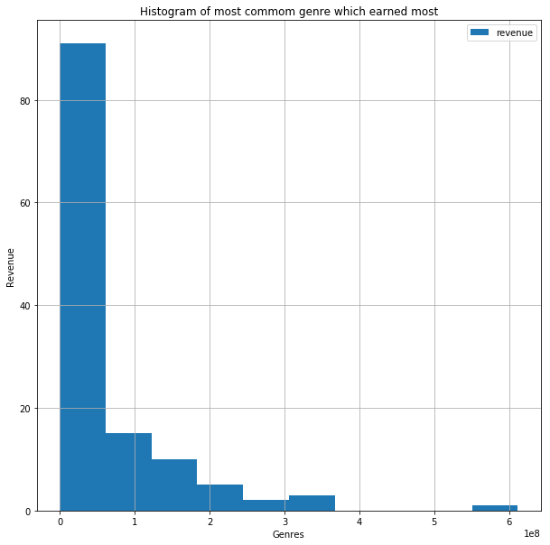

```python
df_drama.plot(x='genres',y='revenue',kind='hist',figsize=(10,10));
plt.xlabel('Genres')
plt.ylabel('Revenue')
plt.title('Histogram of most commom genre which earned most')
plt.grid(True)
plt.show()
```

# Conclusions